# Mutant report

## Equilibration of Glu117Ala model

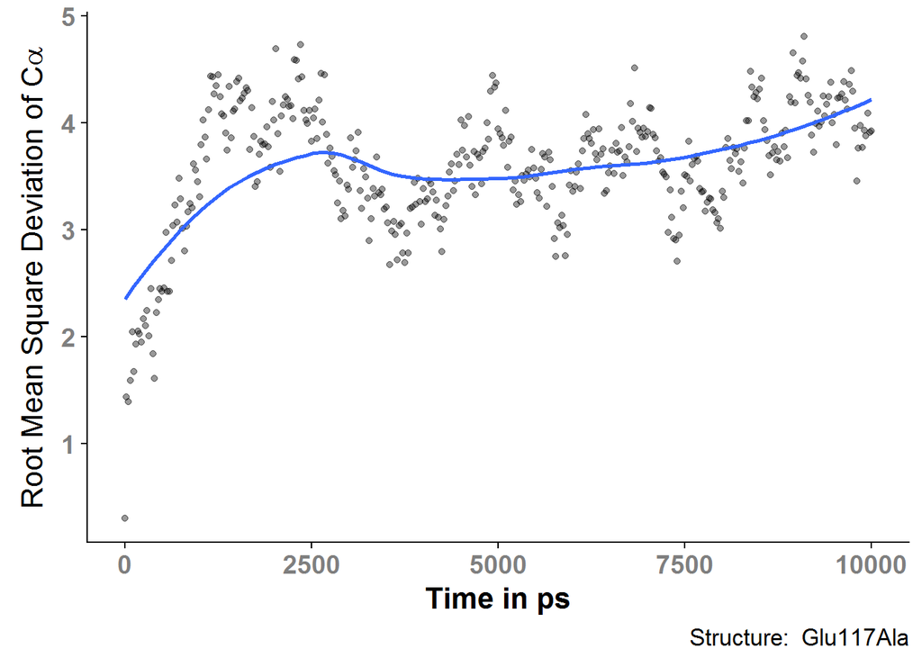

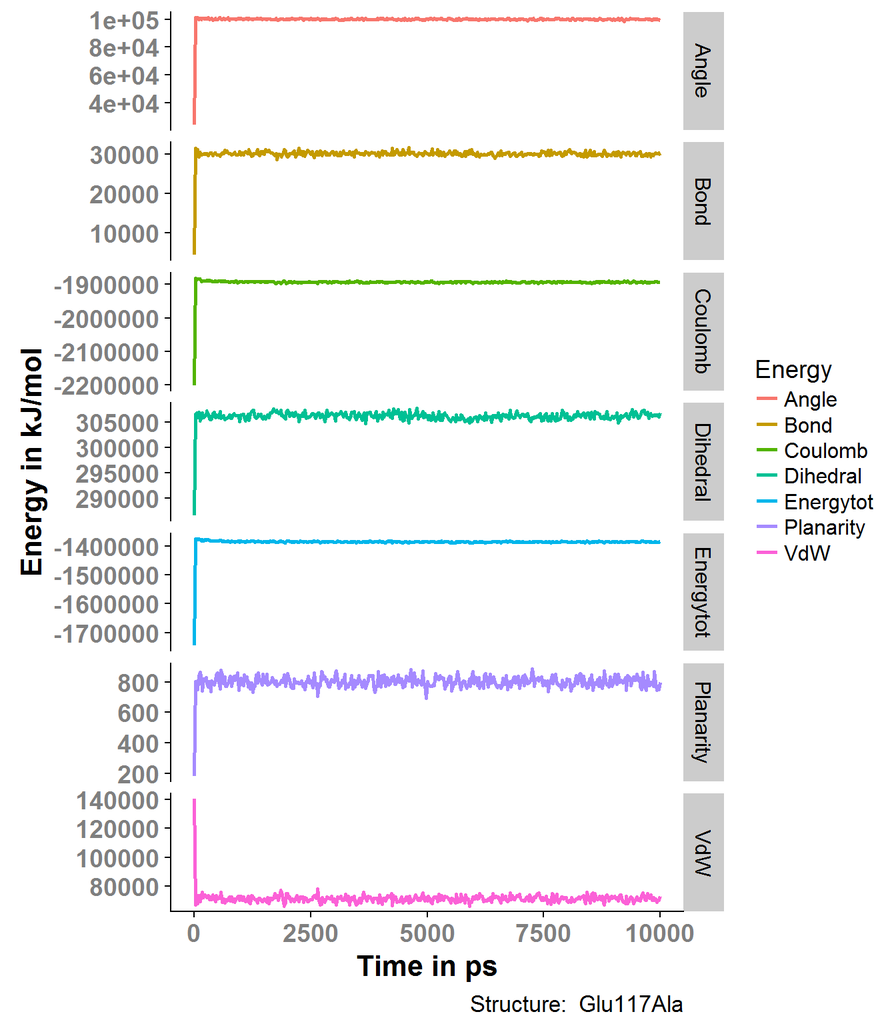

## Energy and Root Mean Square values

|  | Attribute | mean | sd | IQR | max | min |
| --- | --- | --- | --- | --- | --- | --- |
| 1 | Planarity | 800.83 | 44.67 | 48.75 | 886.658 | 182.857 |
| 2 | Dihedral | 306188.9 | 1143.39 | 827.01 | 307740.234 | 286557.986 |
| 3 | Bond | 30087.76 | 1370.15 | 610.12 | 31618.176 | 4309.763 |
| 4 | Angle | 99944.48 | 3813.64 | 560.28 | 101260.54 | 24192.007 |
| 5 | VdW | 71680.57 | 3971.95 | 2702.06 | 140208.273 | 66313.655 |
| 6 | Coulomb | -1893599.01 | 15514.39 | 2282.97 | -1881163.224 | -2200999.909 |
| 7 | Energytot | -1384896.47 | 18174.33 | 2137.63 | -1373119.548 | -1745549.023 |

|  | Attribute | mean | sd | IQR | max | min |
| --- | --- | --- | --- | --- | --- | --- |
| 1 | RMSDbkbn | 3.59 | 0.6 | 0.68 | 4.805 | 0.324 |
| 2 | RMSDca | 3.59 | 0.6 | 0.69 | 4.806 | 0.306 |
| 3 | RMSDheavy | 3.84 | 0.6 | 0.64 | 4.997 | 0.373 |

#### **Data Explanation:**

Model was equilibrated for 10 ns at pH 7.4, 0.9% NaCl, 298K, with a density of 0.997 using an AMBER14 forcefield. The interactions cutoff was 12 angstroms in a cell with periodic boundaries extending 15 angstroms from the ectodomain. Explicit solvent was used in all simulations.

## Secondary Structure Analysis

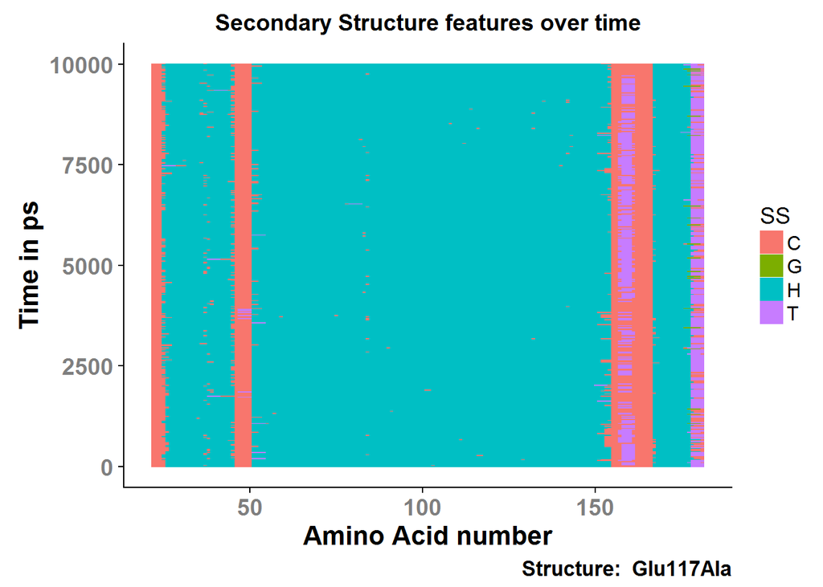

|  | ResNum | Mol | AA | helix | turn | coil |
| --- | --- | --- | --- | --- | --- | --- |
| 1 | 22 | B | LEU | 0 | 0 | 100 |
| 2 | 23 | B | LEU | 0 | 0 | 100 |
| 3 | 24 | A | LEU | 0 | 0 | 100 |
| 4 | 24 | B | LEU | 0 | 0 | 100 |
| 5 | 25 | A | GLY | 81.3 | 0 | 18.7 |
| 6 | 25 | B | GLY | 44.4 | 0.2 | 55.4 |
| 7 | 26 | A | ILE | 97.3 | 0 | 2.7 |
| 8 | 26 | B | ILE | 91.5 | 0.2 | 8.2 |
| 9 | 27 | A | GLY | 98.8 | 0 | 1.2 |
| 10 | 27 | B | GLY | 97.8 | 0.2 | 2 |

[output cut: 307 more lines]

#### **Data Explanation:**

Secondary structures were assigned by YASARA using the md_analyzesecstr macro. As seen, ‘H’ stands for alpha helix, ‘T’ for turn, ‘C’ for coil, ‘E’ for beta bridge, and ‘G’ for 3/10 helix. Values for each type of structure (helix, turn, coil) were summarized to show the percentage of each secondary structure each amino acid adopted during the simulation.

## Comparison with the wild-type model

### Comparison of Dynamic Cross-Correlation Matrices

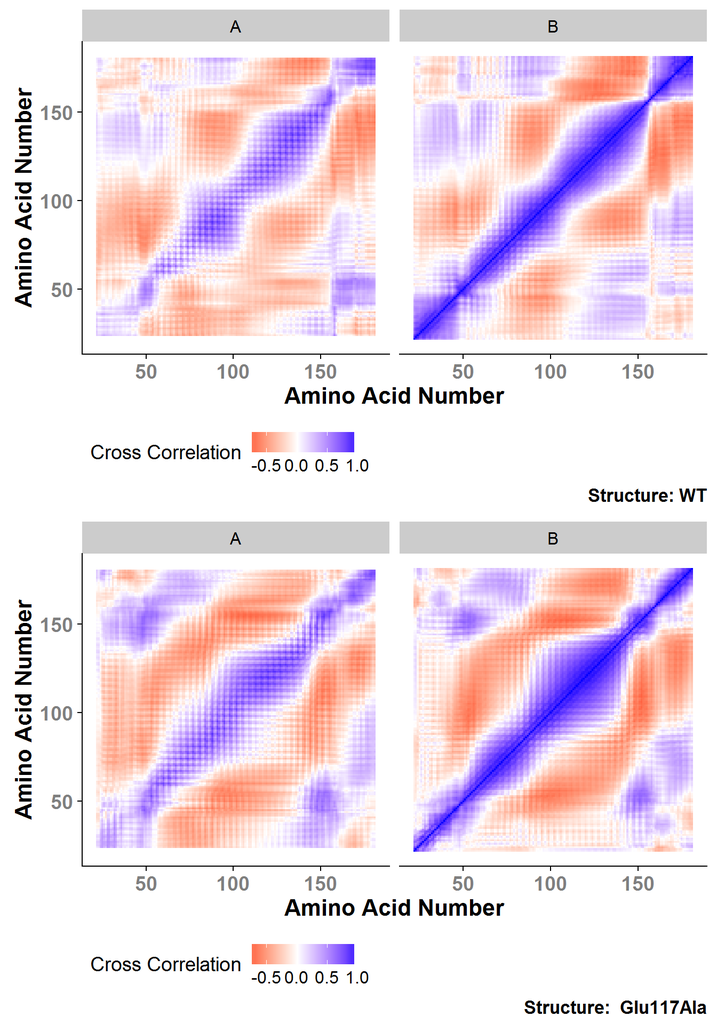

#### **Data Explanation:**

Normalized correlation of amino acid dynamics in the A and B molecules of Tetherin. Blue indicates correlation and red indicates anticorrelation on scale of 1 (correlated) to -1 (anti-correlated).

### Comaprison of per Residue Root Mean Square Flucuations

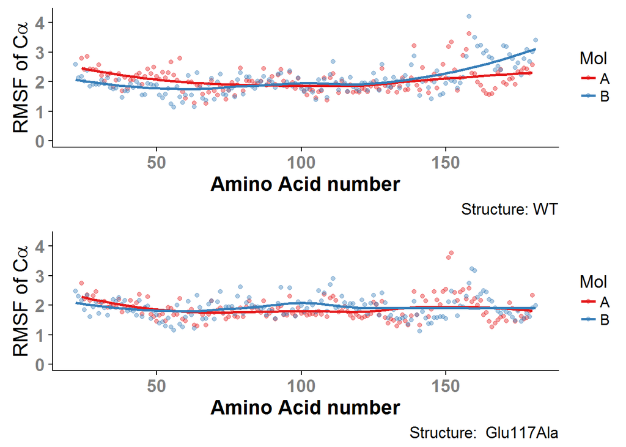

#### **Data Explanation:**

RMSF (Root Mean Square Flucuation) indicates the relative mobility of each amino acid during the 10 ns simulation. Data are colored according to which molecule the amino acid resides within.

### Correlation of RMSF

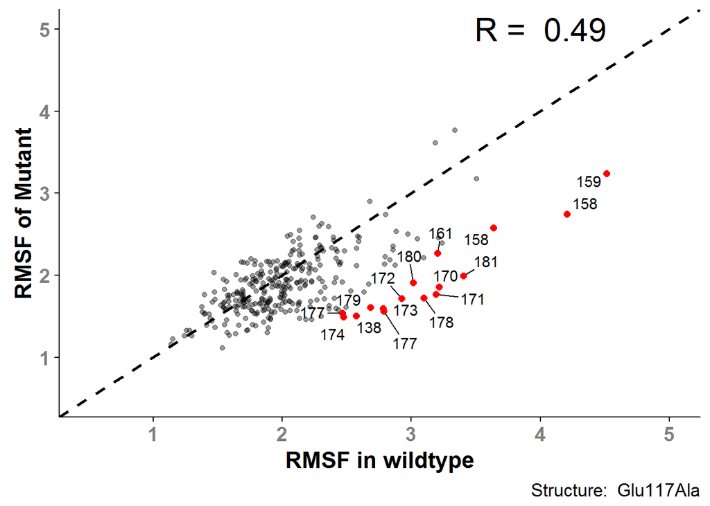

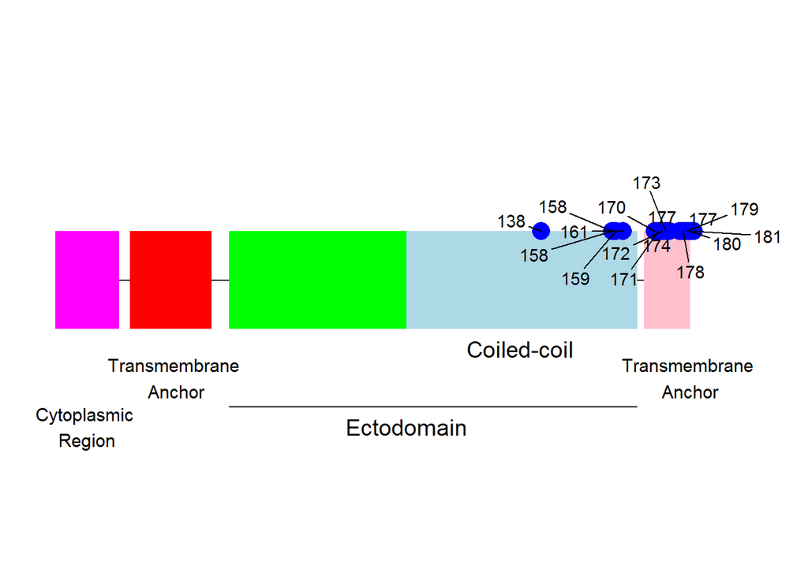

#### **Data Explanation:**

RMSF values for both molecules in the wild-type Tetherin (x-axis) and Glu117Ala Tetherin (y-axis) were plotted against each other to show correlation. The dashed line indicates perfect correlation between the simulations. Outliers were calculated as differences between wildtype and mutant RMSF values that were > 2 standard deviations above the average deviation between the values. Outliers are further plotted on a schematic showing the location within the Tetherin structure.

### Comparison of Secondary Structure

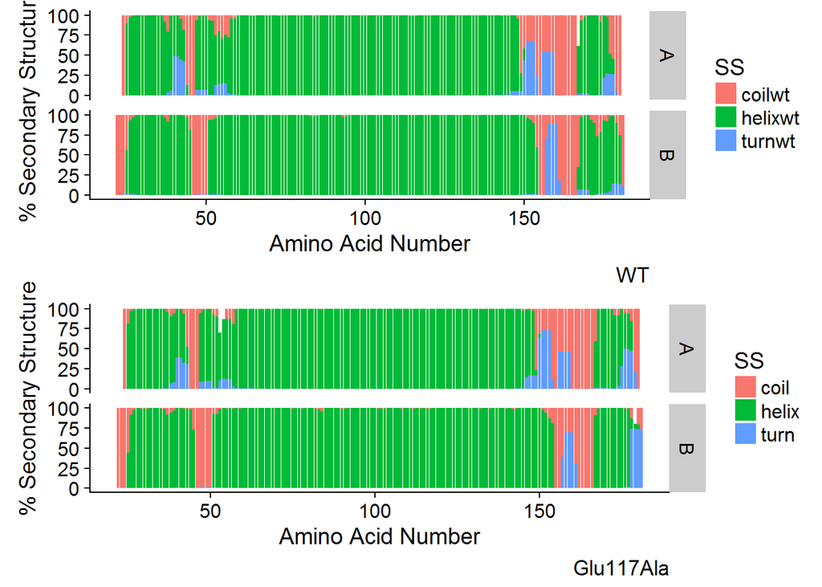

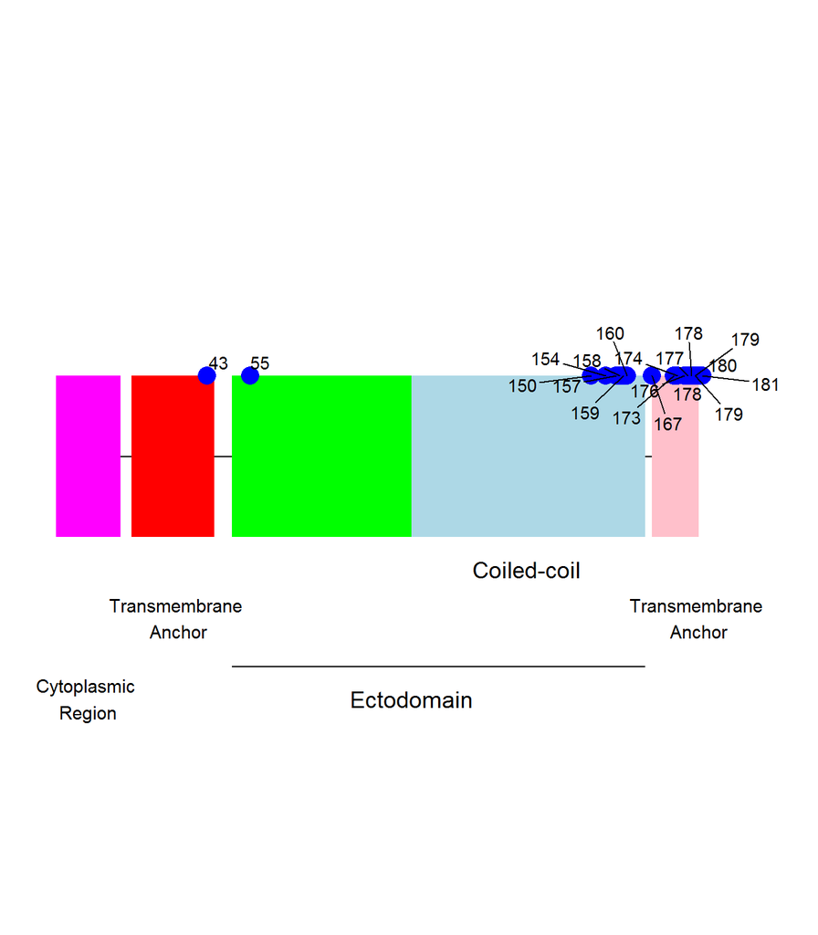

#### **Data Explanation:**

Comparison of secondary structure over time between Glu117Ala and wildtype Tetherin. Outliers were calculated as differences between wildtype and mutant percentage in each secondary structure that were > 2 standard deviations above the average deviation between the values. Outliers are further plotted on a schematic showing the location within the Tetherin structure.